# EXPERIMENT 3: Frequent Item Set Mining

Pattern mining consists of using/developing data mining algorithms to discover interesting, unexpected and useful patterns in databases. Pattern mining is a broad spectrum with many algorithms falling under this umbrella. One such technique is Frequent item set mining and FP Growth is an algorithm belonging to this category. It is designed to be applied on a database that contains transactions to discover patterns made by customers in stores. The main task is to find all common sets of items, defined as itemsets that have occured a minimum number of times.

Applying FP Growth algorithm to the spice-disease data gave frequent itemsets, but, the itemsets obtained were redundant. For instance, some of the smaller itemsets were already a part of the bigger itemsets. Thus a slightly restrictive algorithm was applied by the name of FP Close. A FP Closed itemset is a frequent itemset that is not included in a proper superset having exactly the same support. In order to further stricten the constraints, FP Max was applied. A FP Max itemset is a frequent itemset that is not included in a proper superset that is a frequent itemset.

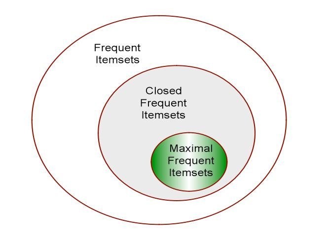

```python
from IPython.display import Image
Image(filename='venndiag.jpg')
```

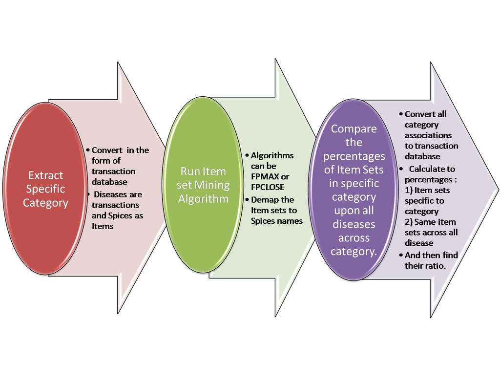

```python
## Below is the Flow Chart of the Experiment 3 that we will Perform.
from IPython.display import Image
Image(filename='Flow_chart.png')
```

### Step1

In this Experiment the question that we are trying to answer is :  
**What are the spices that have more benevolent effect for a specific category of disease as compared to all the disease accross all categories?**

```python
## Code to extract Spice-Diseas Associations specific to a Category.
my_file = open('most-associations-each-level.tsv','r')
lines = my_file.readlines()

spices = []
diseases = []
tree_num = []
count = []
for line in lines:
    temp_list = line.split('\t')
    temp_list1 = temp_list[1].split('.')
    if temp_list[1].count(".") == 0 or temp_list[1].count(".") == 1 or temp_list[1].count(".") == 2:
    #if temp_list[1].count(".") == 0:
        if temp_list1[0] == 'C17':
    #if temp_list[1].count(".") == 2:
            tree_num.append(temp_list[1])
            spices.append(temp_list[2])
            diseases.append(temp_list[4])
            count.append(temp_list[3])

tree_num.pop(0)
spices.pop(0)
diseases.pop(0)
count.pop(0)

my_out_file = open('C17-category-asssociations.tsv','w')
for i in range(len(tree_num)):
    my_out_file.write(str(tree_num[i]) + "\t" + str(spices[i]) + "\t" + str(count[i]) + "\t" + str(diseases[i]))

my_out_file.close()
```

```python
import pandas as pd
df1 = pd.read_csv("C17-category-asssociations.tsv",  sep='\t')
```

```python
df1
```

|  | C17 | Allium sativum | 16 | Skin and Connective Tissue Diseases |
| --- | --- | --- | --- | --- |
| 0 | C17 | Glycyrrhiza glabra | 15 | Skin and Connective Tissue Diseases |
| 1 | C17 | Ginkgo biloba | 13 | Skin and Connective Tissue Diseases |
| 2 | C17 | Oenothera biennis | 12 | Skin and Connective Tissue Diseases |
| 3 | C17 | Nigella sativa | 11 | Skin and Connective Tissue Diseases |
| 4 | C17 | Thymus vulgaris | 10 | Skin and Connective Tissue Diseases |
| 5 | C17 | Zingiber officinale | 8 | Skin and Connective Tissue Diseases |
| 6 | C17 | Cinnamomum aromaticum | 7 | Skin and Connective Tissue Diseases |
| 7 | C17 | Borago officinalis | 7 | Skin and Connective Tissue Diseases |
| 8 | C17 | Coriandrum sativum | 7 | Skin and Connective Tissue Diseases |
| 9 | C17 | Helianthus annuus | 7 | Skin and Connective Tissue Diseases |
| 10 | C17 | Juniperus communis | 7 | Skin and Connective Tissue Diseases |
| 11 | C17 | Persea americana | 6 | Skin and Connective Tissue Diseases |
| 12 | C17 | Carthamus tinctorius | 6 | Skin and Connective Tissue Diseases |
| 13 | C17 | Plectranthus amboinicus | 5 | Skin and Connective Tissue Diseases |
| 14 | C17 | Syzygium aromaticum | 5 | Skin and Connective Tissue Diseases |
| 15 | C17 | Linum usitatissimum | 5 | Skin and Connective Tissue Diseases |
| 16 | C17 | Capsicum annuum | 4 | Skin and Connective Tissue Diseases |
| 17 | C17 | Sesamum indicum | 4 | Skin and Connective Tissue Diseases |
| 18 | C17 | Eutrema japonicum | 4 | Skin and Connective Tissue Diseases |
| 19 | C17 | Crocus sativus | 4 | Skin and Connective Tissue Diseases |
| 20 | C17 | Matricaria chamomilla | 4 | Skin and Connective Tissue Diseases |
| 21 | C17 | Chamaemelum nobile | 4 | Skin and Connective Tissue Diseases |
| 22 | C17 | Cinnamomum verum | 3 | Skin and Connective Tissue Diseases |
| 23 | C17 | Rhus coriaria | 3 | Skin and Connective Tissue Diseases |
| 24 | C17 | Pistacia lentiscus | 3 | Skin and Connective Tissue Diseases |
| 25 | C17 | Salvia officinalis | 3 | Skin and Connective Tissue Diseases |
| 26 | C17 | Lavandula angustifolia | 3 | Skin and Connective Tissue Diseases |
| 27 | C17 | Melissa officinalis | 3 | Skin and Connective Tissue Diseases |
| 28 | C17 | Origanum vulgare | 3 | Skin and Connective Tissue Diseases |
| 29 | C17 | Salvia rosmarinus | 3 | Skin and Connective Tissue Diseases |
| ... | ... | ... | ... | ... |
| 411 | C17.800.859 | Oenothera biennis | 1 | Skin Diseases, Papulosquamous |
| 412 | C17.800.859 | Capsicum frutescens | 1 | Skin Diseases, Papulosquamous |
| 413 | C17.800.859 | Portulaca oleracea | 1 | Skin Diseases, Papulosquamous |
| 414 | C17.800.859 | Allium sativum | 1 | Skin Diseases, Papulosquamous |
| 415 | C17.800.859 | Glycyrrhiza glabra | 1 | Skin Diseases, Papulosquamous |
| 416 | C17.800.859 | Thymus vulgaris | 1 | Skin Diseases, Papulosquamous |
| 417 | C17.800.859 | Cuminum cyminum | 1 | Skin Diseases, Papulosquamous |
| 418 | C17.800.859 | Nigella sativa | 1 | Skin Diseases, Papulosquamous |
| 419 | C17.800.859 | Juniperus communis | 1 | Skin Diseases, Papulosquamous |
| 420 | C17.800.859 | Crocus sativus | 1 | Skin Diseases, Papulosquamous |
| 421 | C17.800.859 | Zingiber officinale | 1 | Skin Diseases, Papulosquamous |
| 422 | C17.800.859 | Matricaria chamomilla | 1 | Skin Diseases, Papulosquamous |
| 423 | C17.800.862 | Artemisia vulgaris | 1 | Skin Diseases, Vascular |
| 424 | C17.800.862 | Zingiber officinale | 1 | Skin Diseases, Vascular |
| 425 | C17.800.865 | Helianthus annuus | 1 | Skin Diseases, Vesiculobullous |
| 426 | C17.800.865 | Trachyspermum ammi | 1 | Skin Diseases, Vesiculobullous |
| 427 | C17.800.882 | Elettaria cardamomum | 1 | Skin Neoplasms |
| 428 | C17.800.882 | Cinnamomum aromaticum | 1 | Skin Neoplasms |
| 429 | C17.800.882 | Curcuma longa | 1 | Skin Neoplasms |
| 430 | C17.800.882 | Schinus terebinthifolia | 1 | Skin Neoplasms |
| 431 | C17.800.882 | Ginkgo biloba | 1 | Skin Neoplasms |
| 432 | C17.800.882 | Carthamus tinctorius | 1 | Skin Neoplasms |
| 433 | C17.800.882 | Allium sativum | 1 | Skin Neoplasms |
| 434 | C17.800.882 | Glycyrrhiza glabra | 1 | Skin Neoplasms |
| 435 | C17.800.882 | Eutrema japonicum | 1 | Skin Neoplasms |
| 436 | C17.800.882 | Alpinia galanga | 1 | Skin Neoplasms |
| 437 | C17.800.882 | Zingiber officinale | 1 | Skin Neoplasms |
| 438 | C17.800.893 | Plectranthus amboinicus | 2 | Skin Ulcer |
| 439 | C17.800.893 | Curcuma longa | 1 | Skin Ulcer |
| 440 | C17.800.946 | Nuphar lutea | 1 | Sweat Gland Diseases |

441 rows × 4 columns

### Step 2

Form the EDGE file.

```python
## We then map Spices and Diseases of the above file with number and form the Edge.txt file
## Below is the code:

class Spice:
    def __init__(self, id, name):
        self.id = id
        self.name = name


class Disease:
    def __init__(self, id, name):
        self.id = id
        self.name = name


my_file = open('C17-category-asssociations.tsv','r')
lines = my_file.readlines()

spices = []
diseases = []
for line in lines:
    temp_list = line.split('\t')
    spices.append(temp_list[1])
    diseases.append(temp_list[3])

# spices.pop(0)
# diseases.pop(0)
spices = list(set(spices))
diseases = list(set(diseases))

disease_mapped_list = []
i = 1
for d in diseases:
    disease = Disease(i, d)
    disease_mapped_list.append(disease)
    i += 1

spice_mapped_list = []
i = len(diseases) + 1
for s in spices:
    spice = Spice(i, s)
    spice_mapped_list.append(spice)
    i += 1

j = 0
for s in spice_mapped_list:
    if j == 0:
        my_spice_file = open('Spice_category_C17.txt', 'w')
        my_spice_file.write(str(s.id) + ' ' + s.name + '\n')
        j += 1
    else:
        my_spice_file = open('Spice_category_C17.txt', 'a')
        my_spice_file.write(str(s.id) + ' ' + s.name + '\n')
j = 0
for d in disease_mapped_list:
    if j == 0:
        my_spice_file = open('Disease_category_C17.txt', 'w')
        my_spice_file.write(str(d.id) + ' ' + d.name + '\n')
        j += 1
    else:
        my_spice_file = open('Disease_category_C17.txt', 'a')
        my_spice_file.write(str(d.id) + ' ' + d.name + '\n')

edge = []
for line in lines:
    temp_list = line.split('\t')
    spice_name = temp_list[1]
    disease_name = temp_list[3]
    if spice_name == 'Spice' and disease_name == 'Disease':
        continue
    for s in spice_mapped_list:
        if s.name == spice_name:
            spice_id = s.id
            break
    for d in disease_mapped_list:
        if d.name == disease_name:
            disease_id = d.id
            break
    el = []
    el.append(spice_id)
    el.append(disease_id)
    edge.append(el)

j = 0
for e in edge:
    if j == 0:
        my_edge_file = open('Edge_category_C17.txt', 'w')
        my_edge_file.write(str(e[0]) + ' ' + str(e[1]) + '\n')
        j += 1
    else:
        my_edge_file = open('Edge_category_C17.txt', 'a')
        my_edge_file.write(str(e[0]) + ' ' + str(e[1]) + '\n')
```

```python
import pandas as pd
df2 = pd.read_csv("Edge_category_C17.txt",  sep=' ', names = ["Spice", "Disease"])
```

```python
df2
```

|  | Spice | Disease |
| --- | --- | --- |
| 0 | 103 | 28 |
| 1 | 56 | 28 |
| 2 | 40 | 28 |
| 3 | 107 | 28 |
| 4 | 89 | 28 |
| 5 | 48 | 28 |
| 6 | 99 | 28 |
| 7 | 42 | 28 |
| 8 | 63 | 28 |
| 9 | 58 | 28 |
| 10 | 60 | 28 |
| 11 | 72 | 28 |
| 12 | 106 | 28 |
| 13 | 110 | 28 |
| 14 | 102 | 28 |
| 15 | 36 | 28 |
| 16 | 105 | 28 |
| 17 | 37 | 28 |
| 18 | 76 | 28 |
| 19 | 84 | 28 |
| 20 | 73 | 28 |
| 21 | 39 | 28 |
| 22 | 47 | 28 |
| 23 | 101 | 28 |
| 24 | 75 | 28 |
| 25 | 95 | 28 |
| 26 | 80 | 28 |
| 27 | 70 | 28 |
| 28 | 104 | 28 |
| 29 | 52 | 28 |
| ... | ... | ... |
| 412 | 107 | 1 |
| 413 | 41 | 1 |
| 414 | 32 | 1 |
| 415 | 103 | 1 |
| 416 | 56 | 1 |
| 417 | 48 | 1 |
| 418 | 62 | 1 |
| 419 | 89 | 1 |
| 420 | 72 | 1 |
| 421 | 73 | 1 |
| 422 | 99 | 1 |
| 423 | 39 | 1 |
| 424 | 81 | 21 |
| 425 | 99 | 21 |
| 426 | 60 | 2 |
| 427 | 57 | 2 |
| 428 | 54 | 13 |
| 429 | 42 | 13 |
| 430 | 78 | 13 |
| 431 | 33 | 13 |
| 432 | 40 | 13 |
| 433 | 110 | 13 |
| 434 | 103 | 13 |
| 435 | 56 | 13 |
| 436 | 84 | 13 |
| 437 | 82 | 13 |
| 438 | 99 | 13 |
| 439 | 102 | 12 |
| 440 | 78 | 12 |
| 441 | 93 | 18 |

442 rows × 2 columns

### Step 3

Form the Transaction Database.

#### What is FPClose?

FPClose is an algorithm of the FPGrowth familly of algorithms, designed for mining frequent closed itemsets. FPClose is supposed to be one of the fastest closed itemset mining algorithm. In this implementations,we have attempted to implement most of the optimizations proposed in the FPClose paper, except that we did not implement the triangular matrix from FPGrowth and the local CFI trees. These optimizations may be added in a future version of SPMF.

#### What is FPMax?

FPMax is an algorithm for discovering frequent maximal itemsets in a transaction database.

FPMax is based on the famous FPGrowth algorithm and includes several strategies for mining maximal itemsets efficiently while pruning the search space.

#### INPUT

The input is a transaction database and a threshold named minsup (a value between 0 and 100 %).

A transaction database is a set of transactions. Each transaction is a set of items. For example, consider the following transaction database. It contains 5 transactions (t1, t2, ..., t5) and 5 items (1,2, 3, 4, 5). For example, the first transaction represents the set of items 1, 3 and 4. This database is provided as the file contextPasquier99.txt in the SPMF distribution. It is important to note that an item is not allowed to appear twice in the same transaction and that items are assumed to be sorted by lexicographical order in a transaction.

```python
#INPUT Format
df4 = pd.DataFrame({'Items' : ('{1, 3, 4}','{2, 3, 5}', '{1, 2, 3, 5}', '{2, 5}', '{1, 2, 3, 5}'),
                    'Transaction id' : ('t1','t2','t3','t4','t5'),})
```

```python
df4.sort_index(axis=1, ascending=False)
```

|  | Transaction id | Items |
| --- | --- | --- |
| 0 | t1 | {1, 3, 4} |
| 1 | t2 | {2, 3, 5} |
| 2 | t3 | {1, 2, 3, 5} |
| 3 | t4 | {2, 5} |
| 4 | t5 | {1, 2, 3, 5} |

```python
## We then convert the edge text file as the input for the ITEM SET INING ALGORITHM that we will will be applying ahead.
## Below is the code for converting the Edge.txt file in the form of Transaction Database:

edgefile = open("Edge_category_C17.txt",'r')
edgeread = edgefile.readlines()
j = 0
for i in range(1,49):
    spicelist=[]
    for edge in edgeread:
        edgelist = edge.split()
        if(i == int(edgelist[1])):
            spicelist.append(edgelist[0])

    if(j == 0):
        edgewrite = open("Mining_input_category_C17.txt", 'w')
        spicelist = list(set(spicelist))
        for spice in spicelist:
            edgewrite.write(str(spice) + " ")
        edgewrite.write("\n")
        j += 1
    else:
        edgewrite = open("Mining_input_category_C17.txt", 'a')
        spicelist = list(set(spicelist))
        for spice in spicelist:
            edgewrite.write(str(spice) + " ")
        edgewrite.write("\n")
```

```python
import pandas as pd
df3 = pd.read_csv("Mining_input_category_C17.txt", names = ["Transactions(Spice Ids)"])
```

```python
df3
```

|  | Transactions(Spice Ids) |
| --- | --- |
| 0 | 102 41 32 89 99 72 56 48 39 70 104 107 62 40 1... |
| 1 | 57 60 |
| 2 | 52 89 111 48 36 38 70 104 117 80 119 78 58 103... |
| 3 | 89 74 95 56 36 110 84 107 63 75 78 48 60 40 |
| 4 | 78 87 40 72 |
| 5 | 106 |
| 6 | 102 116 95 56 65 103 |
| 7 | 86 |
| 8 | 78 87 40 72 |
| 9 | 40 |
| 10 | 56 63 76 58 47 |
| 11 | 102 78 |
| 12 | 99 82 56 110 84 40 54 33 78 103 42 |
| 13 | 74 72 56 110 84 107 62 63 73 78 48 60 40 |
| 14 | 85 78 103 |
| 15 | 58 103 |
| 16 | 105 32 89 99 39 36 110 107 37 85 78 58 47 42 |
| 17 | 93 |
| 18 | 105 92 89 49 56 107 47 91 101 40 102 88 63 55 ... |
| 19 | 111 104 70 80 64 |
| 20 | 81 99 |
| 21 | 89 74 95 56 36 110 84 107 63 75 78 48 60 40 |
| 22 | 89 39 105 114 56 84 49 70 107 35 38 94 57 54 1... |
| 23 | 78 105 |
| 24 | 62 73 |
| 25 | 106 107 103 |
| 26 | 48 |
| 27 | 39 114 56 70 35 121 91 101 98 102 41 100 87 12... |
| 28 | 105 92 89 49 56 107 47 91 40 101 102 88 63 55 ... |
| 29 | 105 89 114 39 49 56 107 94 121 34 112 91 40 47... |
| 30 | 89 72 56 78 40 |

### Step 4

RUN the Algorithm:

1) If you are using the graphical interface, (A) Choose the "FPClose" algorithm or "FPMax" algorithm, (B) Select the input file "Mining_input_category_x.txt", (C) Set the output file name (e.g. "output.txt") (4) set minsup to 10% and (5) click "Run algorithm".

2) If you want to execute this example from the command line, then execute this command: **java -jar spmf.jar run FPClose contextPasquier99.txt output.txt 40% in a folder containing spmf.jar and the example input file contextPasquier99.txt.**

[figure not shown]

```python
from IPython.display import Image
Image(filename='spmf-itemset.png')
```

#### OUTPUT of FPCLOSE

FPClose outputs frequent closed itemsets. To explain what is a frequent closed itemset, it is necessary to review a few definitions.

An itemset is a unordered set of distinct items. The support of an itemset is the number of transactions that contain the itemset. For example, the itemset {1, 3} has a support of 3 because it appears in three transactions (t1, t3, t5) from the previous transaction database.

A frequent itemset is an itemset that appears in at least minsup transactions from the transaction database.  
A frequent closed itemset is a frequent itemset that is not included in a proper superset having exactly the same support. The set of frequent closed itemsets is thus a subset of the set of frequent itemsets.  
Why is it interesting to discover frequent closed itemsets ?  
The reason is that the set of frequent closed itemsets is usually much smaller than the set of frequent itemsets and it can be shown that no information is lost by discovering only frequent closed itemsets (because all the frequent itemsets can be regenerated from the set of frequent closed itemsets.

If we apply FPClose on the previous transaction database with a minsup of 40 % (2 transactions), we get the following result:

| frequent closed itemsets | support |
| --- | --- |
| {3} | 4 |
| {1, 3} | 3 |
| {2, 5} | 4 |
| {2, 3, 5} | 3 |
| {1, 2, 3, 5} | 2 |

#### OUTPUT of FPMAX

FPMax outputs frequent maximal itemsets. To explain what is a frequent maximal itemset, it is necessary to review a few definitions.

A frequent itemset is an itemset that appears in at least minsup transactions from the transaction database.  
A frequent closed itemset is a frequent itemset that is not included in a proper superset having the same support.  
A frequent maximal itemset is a frequent itemset that is not included in a proper superset that is a frequent itemset. The set of frequent maximal itemsets is thus a subset of the set of frequent closed itemsets, which is a subset of frequent itemsets.  
Why it is interesting to discover frequent maximal itemsets ?  
The reason is that the set of frequent maximal itemsets is usually much smaller than the set of frequent itemsets and also smaller than the set of frequent closed itemsets. However, unlike frequent closed itemsets, frequent maximal itemsets are not a lossless representation of the set of frequent itemsets (it is possible to regenerate all frequent itemsets from the set of frequent maximal itemsets but it would not be possible to get their support without scanning the database).

If we apply FPMax on the previous transaction database with a minsup of 40 % (2 transactions), we get the following result:

[output not shown]

### Step 5

Maps the Item set to thei Spice names.

```python
## Below is the code that maps the numbers in the item sets(as spiceIDs) we get to their spice names.
## The same can be used for FPMAX and FPCLOSE outputs

Item_set_file = open('out_fpmax_c17_10%.txt','r')
spice_file = open("Spice_category_C17.txt", 'r')
Item_set_read = Item_set_file.readlines()
spice_file_read = spice_file.readlines()
Itemset_list = []
for Item_sets in Item_set_read:
    string = ''
    Item_set_list = Item_sets.split('#')
    Item_set = Item_set_list[0].split(" ")
    for item_set in Item_set:
        if item_set != ' ':
            for spice in spice_file_read:
                spice_list = spice.split(" ",1)
                if item_set.rstrip(" ") == spice_list[0]:
                    string += spice_list[1].rstrip('\n')
                    string += ";"

    string = string.rstrip(";") + " #"+ Item_set_list[1]
    Itemset_list.append(string)

write_Itemsets = open("itemset_demap_fpmax_C17(10%).txt", 'w')
for Items in Itemset_list:
    write_Itemsets.write(Items)
```

```python
import pandas as pd
df5 = pd.read_csv("itemset_demap_fpmax_C17(10%).txt", names = ["Spices as itemset)"])
```

```python
df5
```

|  | Spices as itemset) |
| --- | --- |
| 0 | Lavandula angustifolia;Melissa officinalis;Pot... |
| 1 | Ginkgo biloba;Juniperus communis;Berberis vulg... |
| 2 | Mentha x piperita #SUP: 4 |
| 3 | Ginkgo biloba;Glycyrrhiza glabra;Allium sativu... |
| 4 | Ginkgo biloba;Glycyrrhiza glabra;Allium sativu... |
| 5 | Ginkgo biloba;Glycyrrhiza glabra;Allium sativu... |
| 6 | Nigella sativa;Oenothera biennis;Zingiber offi... |
| 7 | Allium sativum;Nigella sativa;Thymus vulgaris;... |
| 8 | Curcuma longa;Ginkgo biloba;Glycyrrhiza glabra... |
| 9 | Ginkgo biloba;Glycyrrhiza glabra;Nigella sativ... |
| 10 | Curcuma longa;Ginkgo biloba;Glycyrrhiza glabra... |
| 11 | Curcuma longa;Ginkgo biloba;Glycyrrhiza glabra... |
| 12 | Curcuma longa;Ginkgo biloba;Glycyrrhiza glabra... |
| 13 | Ginkgo biloba;Glycyrrhiza glabra;Oenothera bie... |
| 14 | Nigella sativa;Oenothera biennis;Coriandrum sa... |
| 15 | Curcuma longa;Nigella sativa;Oenothera biennis... |
| 16 | Curcuma longa;Ginkgo biloba;Glycyrrhiza glabra... |
| 17 | Ginkgo biloba;Glycyrrhiza glabra;Oenothera bie... |
| 18 | Curcuma longa;Ginkgo biloba;Glycyrrhiza glabra... |
| 19 | Allium sativum;Nigella sativa;Coriandrum sativ... |
| 20 | Curcuma longa;Nigella sativa;Thymus vulgaris;S... |
| 21 | Curcuma longa;Nigella sativa;Coriandrum sativu... |
| 22 | Curcuma longa;Zingiber officinale;Cinnamomum a... |
| 23 | Curcuma longa;Ginkgo biloba;Glycyrrhiza glabra... |
| 24 | Curcuma longa;Ginkgo biloba;Glycyrrhiza glabra... |
| 25 | Curcuma longa;Ginkgo biloba;Glycyrrhiza glabra... |

### Step 6

Now our next step is to find the frequency of each ITEM SET that we have obtained above accross all the Disease Category. For this we have to again form the transaction Database (Perform Step 1 to 3) for all the diseases upto 3 levels of Mesh IDs. The Output that we will obtain after this will be again a bigger Transaction Database.

As we saw above that the transaction database that we obtain is in the form of number , we can again map the number to their Spice names by using the below code.

```python
Transaction_file = open('Mining_input_alllevels.txt','r')
spice_file = open("Spice_alllevels.txt", 'r')
Transaction_read = Transaction_file.readlines()
spice_file_read = spice_file.readlines()

Transactionfile_list = []
for transaction in Transaction_read:
    Transaction_list = transaction.split(" ")
    string = ''
    for tr in Transaction_list:
        for spice in spice_file_read:
            spice_list = spice.split(" ", 1)
            if tr.rstrip(" ") == spice_list[0]:
                string += spice_list[1].rstrip('\n')
                string += ";"
                break

    string = string.rstrip(" ") + "\n"
    Transactionfile_list.append(string)

write_Transactionfile = open("transactionfile_demap.txt", 'w')
for transactions in Transactionfile_list:
    write_Transactionfile.write(transactions)
```

```python
import pandas as pd
df6 = pd.read_csv("transactionfile_demap.txt", names = ["Transactions(Spice Names)"])
```

```python
df6
```

|  | Transactions(Spice Names) |
| --- | --- |
| 0 | Piper nigrum;Curcuma zedoaria;Cinnamomum aroma... |
| 1 | Nigella sativa;Plectranthus amboinicus;Ferula ... |
| 2 | Chamaemelum nobile;Ocimum basilicum;Zingiber o... |
| 3 | Trigonella foenum-graecum;Carthamus tinctorius... |
| 4 | Trigonella foenum-graecum;Allium sativum;Helia... |
| 5 | Ginkgo biloba;Juniperus communis;Allium sativum; |
| 6 | Nigella sativa;Salvia officinalis;Curcuma long... |
| 7 | Zingiber officinale;Plectranthus amboinicus;Ci... |
| 8 | Curcuma longa; |
| 9 | Curcuma longa;Glycyrrhiza glabra;Cichorium int... |
| 10 | Ginkgo biloba;Carthamus tinctorius; |
| 11 | Carthamus tinctorius;Allium sativum; |
| 12 | Cinnamomum verum;Cinnamomum aromaticum; |
| 13 | Orchis mascula;Zingiber officinale;Ocimum tenu... |
| 14 | Cinnamomum verum; |
| 15 | Zingiber officinale;Portulaca oleracea;Glycyrr... |
| 16 | Coriandrum sativum;Allium sativum; |
| 17 | Zingiber officinale;Ocimum tenuiflorum; |
| 18 | Ginkgo biloba; |
| 19 | Mentha spicata;Piper nigrum;Curcuma zedoaria;C... |
| 20 | Zingiber officinale;Orchis mascula; |
| 21 | Ginkgo biloba;Ocimum basilicum; |
| 22 | Curcuma zedoaria;Hibiscus sabdariffa;Persea am... |
| 23 | Piper longum;Nigella sativa;Allium sativum;Cur... |
| 24 | Curcuma longa; |
| 25 | Ginkgo biloba;Melissa officinalis;Trigonella f... |
| 26 | Cinnamomum verum;Illicium verum;Curcuma longa; |
| 27 | Nasturtium officinale;Zingiber officinale;Curc... |
| 28 | Piper nigrum;Curcuma zedoaria;Cinnamomum aroma... |
| 29 | Illicium verum;Sesamum indicum;Foeniculum vulg... |
| ... | ... |
| 568 | Ginkgo biloba; |
| 569 | Hibiscus sabdariffa; |
| 570 | Chamaemelum nobile;Mentha spicata;Piper nigrum... |
| 571 | Trachyspermum ammi;Kaempferia galanga;Rhus cor... |
| 572 | Nigella sativa;Allium sativum;Curcuma longa; |
| 573 | Schinus terebinthifolia;Zingiber officinale; |
| 574 | Illicium verum;Sesamum indicum;Borago officina... |
| 575 | Cuminum cyminum;Laurus nobilis;Zingiber offici... |
| 576 | Ginkgo biloba; |
| 577 | Crocus sativus;Curcuma longa; |
| 578 | Ferula assa-foetida; |
| 579 | Chamaemelum nobile;Nigella sativa;Capsicum ann... |
| 580 | Coriandrum sativum;Kaempferia galanga;Salvia r... |
| 581 | Elettaria cardamomum;Nigella sativa;Sesamum in... |
| 582 | Ginkgo biloba; |
| 583 | Piper nigrum;Trachyspermum ammi;Armoracia rust... |
| 584 | Zingiber officinale; |
| 585 | Persea americana;Allium sativum; |
| 586 | Ruta graveolens;Berberis vulgaris;Zingiber off... |
| 587 | Allium sativum;Piper longum;Oenothera biennis;... |
| 588 | Nigella sativa;Ocimum basilicum;Gynostemma pen... |
| 589 | Origanum vulgare; |
| 590 | Cinnamomum aromaticum;Hibiscus sabdariffa;Arte... |
| 591 | Piper nigrum;Trachyspermum ammi;Allium fistulo... |
| 592 | Berberis vulgaris;Curcuma longa;Helianthus ann... |
| 593 | Nigella sativa;Salvia officinalis;Borago offic... |
| 594 | Zingiber officinale;Curcuma longa; |
| 595 | Mentha spicata;Satureja montana;Kaempferia gal... |
| 596 | Sesamum indicum;Coriandrum sativum;Ocimum tenu... |
| 597 | Nigella sativa;Ocimum basilicum;Ferula assa-fo... |

598 rows × 1 columns

### Step 7

```python
threshold = 10.0

item_set_file = open('itemset_demap_fpmax_C17(10%).txt', 'r')
transaction_file = open('transactionfile_demap.txt')
disease_file = open('Disease_category_C17.txt','r')
disease_file_read = disease_file.readlines()
disease_file_all = open('Disease_alllevels.txt','r')
disease_file_all_read = disease_file_all.readlines()

is_lines = item_set_file.readlines()
tf_lines = transaction_file.readlines()

list_of_lists = []
for tf_line in tf_lines:
    list_of_lists.append(tf_line.split(';'))

my_dict_generic = {}
my_dict_specific = {}
for is_line in is_lines:
    counter = 0
    temp1 = is_line.split(' #SUP: ')
    temp_items = temp1[0].split(";")
    my_dict_specific[' '.join(temp_items)] = int(temp1[1].strip())
    my_dict_generic[' '.join(temp_items)] = counter

    for inner_list in list_of_lists:
        flag = 0
        for temp_item in temp_items:
            if temp_item not in inner_list:
                flag = 1
                break
        if flag == 0:
            my_dict_generic[' '.join(temp_items)] += 1

count = 0
for key, val in my_dict_generic.items():
    specific_count = my_dict_specific[key]
    length = len(disease_file_read)/2
    specific_count_percentage = specific_count*1.0/(length)*100
    if val > 0:
        length1 = len(disease_file_all_read)/2
        all_percentage = val/length1*100
        frac = (specific_count_percentage*1.0)/all_percentage
        if frac >= threshold:
            print (key + ' ' + str(frac))
            count += 1
print ('Number of such item sets = ' + str(count))
```

[output not shown]